# An Introduction to Insurance Pricing, GLMs and Model Validation

Dublin Data Science

Mick Cooney mickcooney@gmail.com

2017-08-24

# Background

# Computational Actuarial Science

[figure not shown]

# Insurance Business

Life Insurance

General Insurance

(Health Insurance)

Pay premia

If event occurs, receive payout

How do we calculate premia?

How *SHOULD* we calculate premia?

$$\text{Price} = E(\text{Loss}) + \text{Expenses} + \text{Profit}$$

# Life Insurance

Monthly or annual premia

Contingent annuity

Life Tables

# Pricing General Insurance

Typically 1-year policies

(but not always)

Estimate Loss Cost of a Policy

Frequency / Severity Model

Exposure vs Claims

Heavy use of GLMs

$$\text{Price} = E[\text{Claim Rate}] \times E[\text{Claim Size}]$$

Claim Rate $\longrightarrow$ Poisson

Claim Amount $\longrightarrow$ Gamma

Need policy and claim data

Package `CASDatasets`

`freMPTLfreq` and `freMPTLsev`

More datasets in book

# Data Loading and Exploration

| PolicyID | ClaimNb | Exposure | Power | CarAge | DriverAge | Brand | Gas | Region | Density |
| --- | --- | --- | --- | --- | --- | --- | --- | --- | --- |
| 1 | 0 | 0.09 | g | 0 | 46 | Japanese (except Nissan) or Korean | Diesel | R72 | 76 |
| 2 | 0 | 0.84 | g | 0 | 46 | Japanese (except Nissan) or Korean | Diesel | R72 | 76 |
| 3 | 0 | 0.52 | f | 2 | 38 | Japanese (except Nissan) or Korean | Regular | R31 | 3003 |
| 4 | 0 | 0.45 | f | 2 | 38 | Japanese (except Nissan) or Korean | Regular | R31 | 3003 |
| 5 | 0 | 0.15 | g | 0 | 41 | Japanese (except Nissan) or Korean | Diesel | R52 | 60 |
| 6 | 0 | 0.75 | g | 0 | 41 | Japanese (except Nissan) or Korean | Diesel | R52 | 60 |

```
## Observations: 413,169
## Variables: 10
## $ PolicyID  <int> 1, 2, 3, 4, 5, 6, 7, 8, 9, 10, 11, 12, 13, 14, 15, 16, 17...
## $ ClaimNb   <int> 0, 0, 0, 0, 0, 0, 0, 0, 0, 0, 0, 0, 0, 0, 0, 0, 0, 0, 0, ...
## $ Exposure  <dbl> 0.09, 0.84, 0.52, 0.45, 0.15, 0.75, 0.81, 0.05, 0.76, 0.3...
## $ Power     <fctr> g, g, f, f, g, g, d, d, d, i, f, f, e, e, e, e, e, e, i,...
## $ CarAge    <int> 0, 0, 2, 2, 0, 0, 1, 0, 9, 0, 2, 2, 0, 0, 0, 0, 0, 0, 0, ...
## $ DriverAge <int> 46, 46, 38, 38, 41, 41, 27, 27, 23, 44, 32, 32, 33, 33, 3...
## $ Brand     <fctr> Japanese (except Nissan) or Korean, Japanese (except Nis...
## $ Gas       <fctr> Diesel, Diesel, Regular, Regular, Diesel, Diesel, Regula...
## $ Region    <fctr> R72, R72, R31, R31, R52, R52, R72, R72, R31, R11, R24, R...
## $ Density   <int> 76, 76, 3003, 3003, 60, 60, 695, 695, 7887, 27000, 23, 23...
```

| PolicyID | ClaimAmount |
| --- | --- |
| 63987 | 1172 |
| 310037 | 1905 |
| 314463 | 1150 |
| 318713 | 1220 |
| 309380 | 55077 |
| 309380 | 7593 |
| 318738 | 1176 |
| 305914 | 1202 |
| 313314 | 1203 |
| 309238 | 1232 |
| 314567 | 1224 |
| 308695 | 574 |
| 310208 | 1206 |
| 314049 | 1134 |
| 308943 | 1200 |

# Combine Tables

```r
policy_claims_tbl <- claim_tbl %>%
    group_by(policy_id) %>%
    summarise(claim_count = n()
             ,claim_total = sum(claim_amount))

combined_tbl <- policy_tbl %>%
    left_join(policy_claims_tbl, by = 'policy_id') %>%
    mutate(claim_count = ifelse(is.na(claim_count), 0, claim_count)
          ,claim_total = ifelse(is.na(claim_total), 0, claim_total)
           )
```

| policy_id | claim_nb | exposure | power | car_age | driver_age | brand | gas | region | density | claim_count | claim_total |
| --- | --- | --- | --- | --- | --- | --- | --- | --- | --- | --- | --- |
| 1 | 0 | 0.09 | g | 0 | 46 | Japanese (except Nissan) or Korean | Diesel | R72 | 76 | 0 | 0 |
| 2 | 0 | 0.84 | g | 0 | 46 | Japanese (except Nissan) or Korean | Diesel | R72 | 76 | 0 | 0 |
| 3 | 0 | 0.52 | f | 2 | 38 | Japanese (except Nissan) or Korean | Regular | R31 | 3003 | 0 | 0 |
| 4 | 0 | 0.45 | f | 2 | 38 | Japanese (except Nissan) or Korean | Regular | R31 | 3003 | 0 | 0 |
| 5 | 0 | 0.15 | g | 0 | 41 | Japanese (except Nissan) or Korean | Diesel | R52 | 60 | 0 | 0 |
| 6 | 0 | 0.75 | g | 0 | 41 | Japanese (except Nissan) or Korean | Diesel | R52 | 60 | 0 | 0 |

```r
combined_tbl %>% filter(claim_nb != claim_count)
```

```
## # A tibble: 0 x 12
## # ... with 12 variables: policy_id <int>, claim_nb <int>, exposure <dbl>,
## #   power <fctr>, car_age <int>, driver_age <int>, brand <fctr>, gas <fctr>,
## #   region <fctr>, density <int>, claim_count <dbl>, claim_total <dbl>
```

# Univariate Data Exploration

Look at each variable

Create histograms, bar charts etc

`dataexpks` - data exploration template

### claim_count

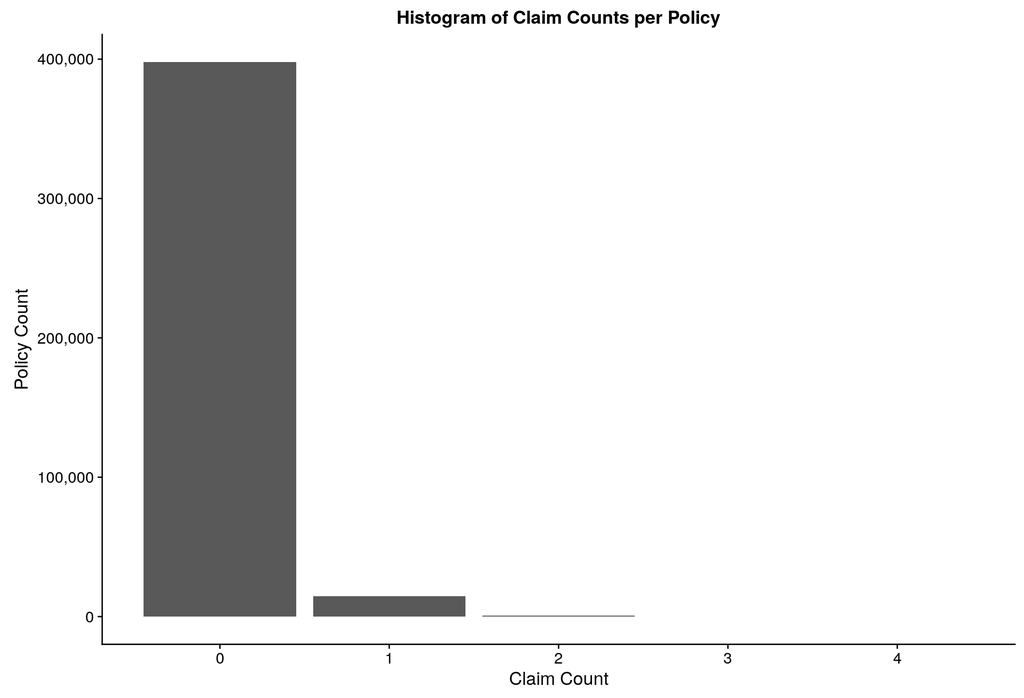

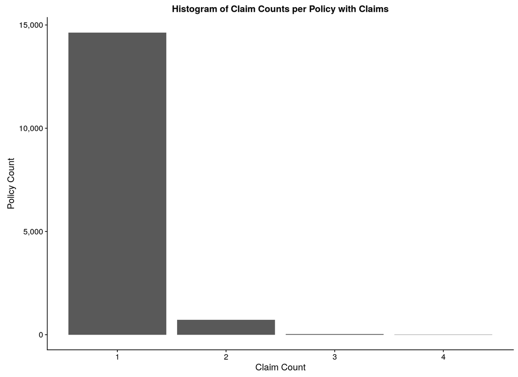

### claim_amount

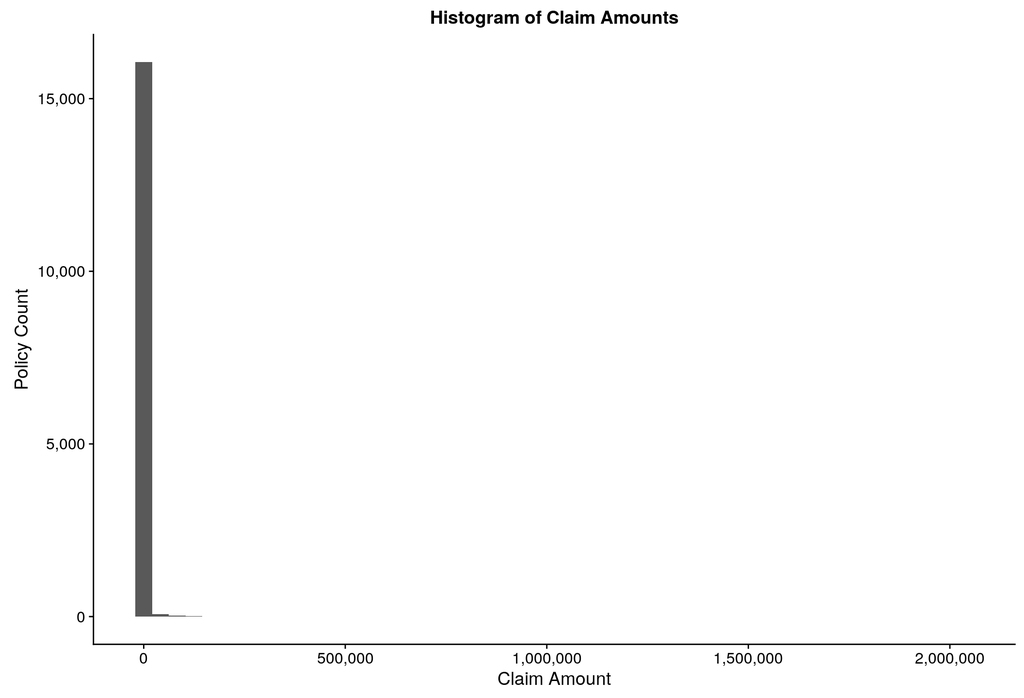

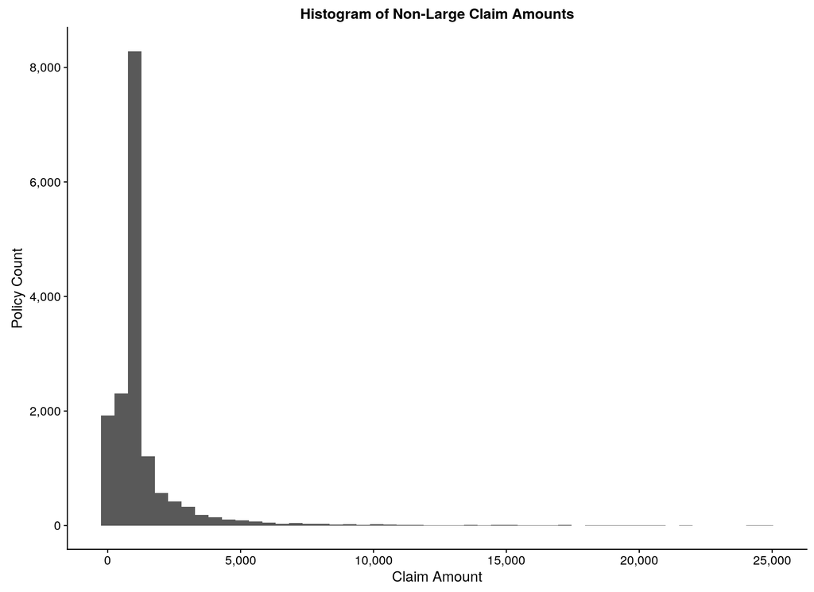

### exposure

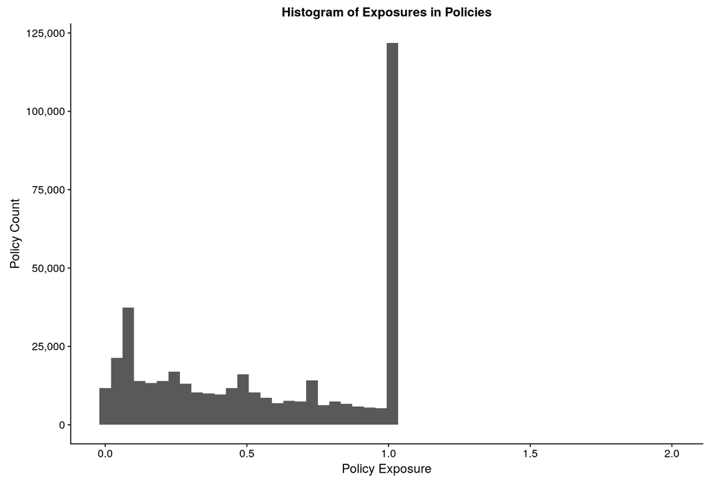

### driver_age

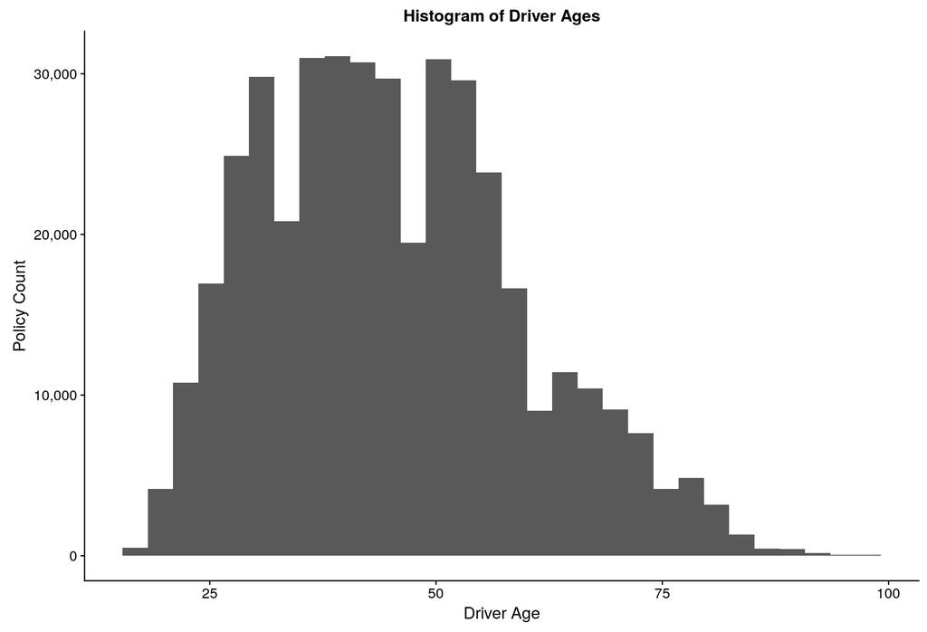

### car_age

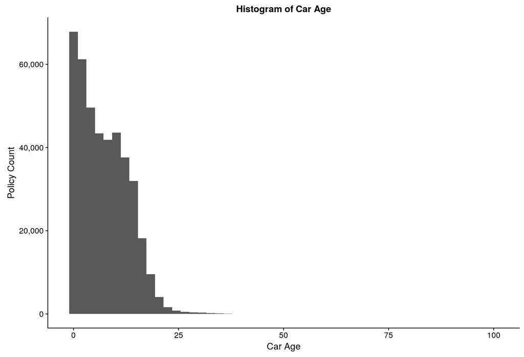

# Bivariate Data Exploration

Look at two variables at once

Boxplots, Scatterplots, Heatmaps, etc

### claim_count vs driver_age

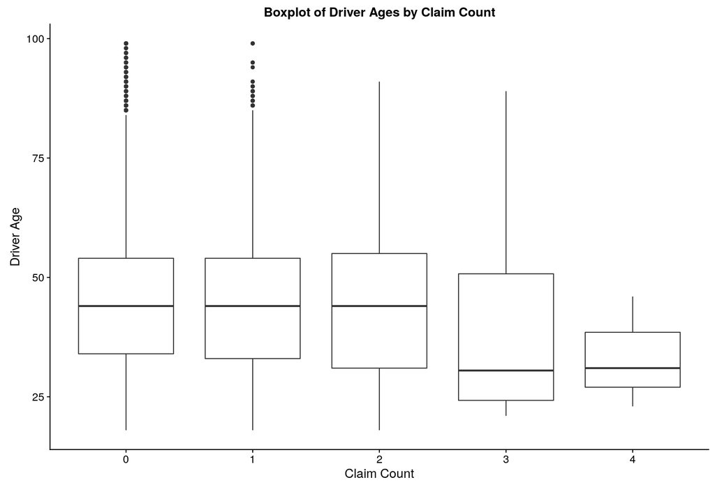

### claim_count vs region

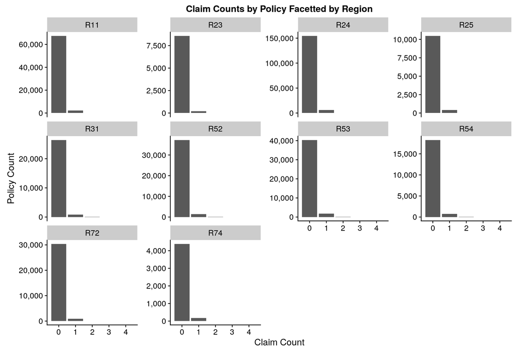

# Estimating Large Losses

Large losses very random

Treat like natural disasters

Power-law scaling

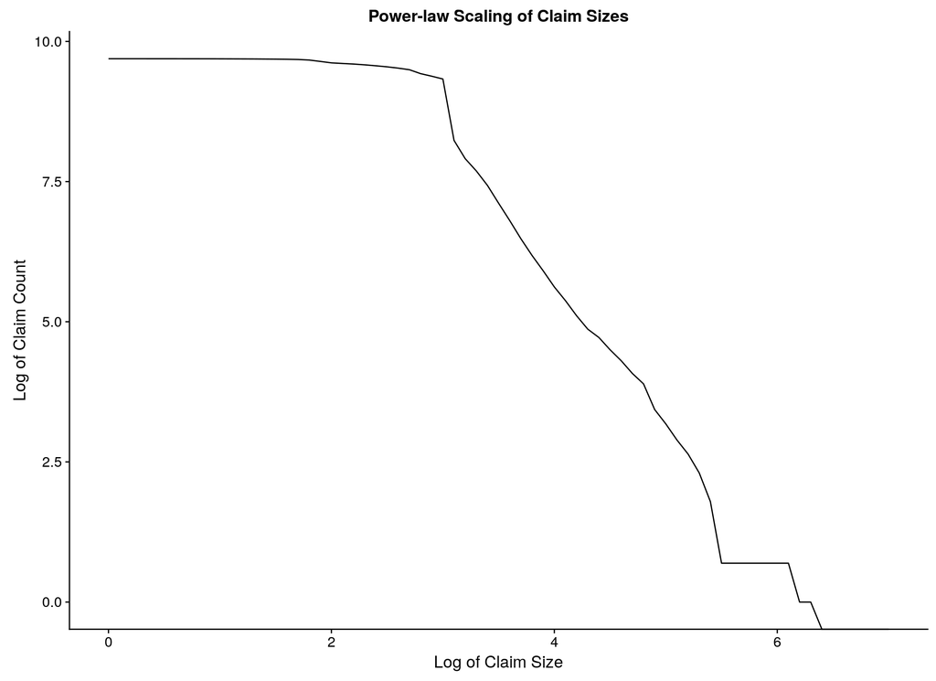

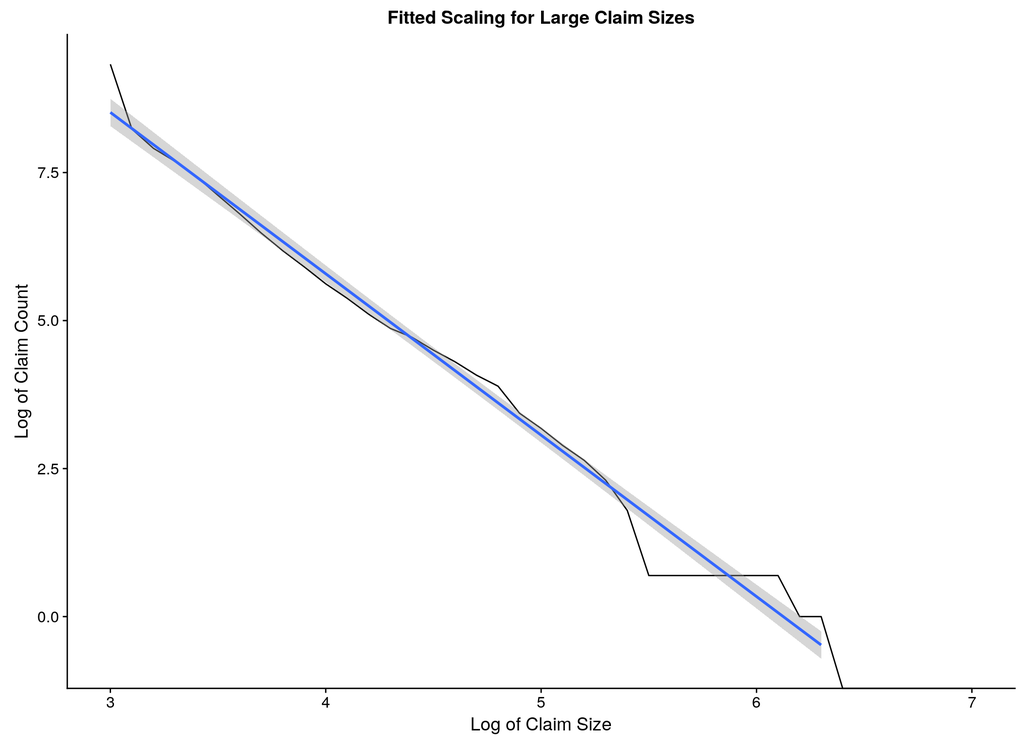

Looks reasonable

Slope is scaling factor, $\alpha$

$\alpha > 2 \; \implies \mu$ finite

$\alpha > 3 \; \implies$ variance finite

Definitely want finite $\mu$…

```r
pl_tbl <- powerlaw_tbl %>%
    filter(logsize >= 3, count > 0) %>%
    mutate(logcount  = log(count))

pl_lm <- lm(logcount ~ logsize, data = pl_tbl)
```

| term | estimate | std.error | statistic | p.value |
| --- | --- | --- | --- | --- |
| (Intercept) | 16.69516 | 0.280658 | 59.4858 | 0 |
| logsize | -2.72615 | 0.059056 | -46.1618 | 0 |

Finite $\mu$, non-finite $\text{Var}(x)$

# Proposed Approach

# Model Attritional Losses

Use Poisson / Gamma models for rate / size

Estimate of attritional loss cost

Each policy has ‘fitted’ estimate

# Model Catastrophic Losses

Use power-law distribution

Estimate rate of large losses

Use mean loss to calculate flat charge

# Generalized Linear Models

# Basic Concept

$$\begin{eqnarray*}
E(\mathbf{Y}) &=& \mu = g^{-1}(\text{X} \beta) \\
\text{Var}(\mathbf{Y}) &=& V(\mu)
\end{eqnarray*}$$

where

$$\begin{align*}
\mathbf{Y} &= \text{response variable} \\
\mathbf{X} &= \text{predictor variables} \\
\beta &= \text{model coefficients} \\
g(x) &= \text{link function} \\
V(x) &= \text{variance function} \\
\end{align*}$$

Combines multiple forms of regression

$$\begin{eqnarray*}
\text{Linear regression} &\longrightarrow & g(x) = x \\
\\
\text{Poisson regression} &\longrightarrow & g(x) = \log(x) \\
\\
\text{Gamma regression} &\longrightarrow & g(x) = \frac{1}{x}
\end{eqnarray*}$$

# Modelling Claim Rate

Assume Poisson process

Predict per-policy poisson rate

Many possible models

### Overall Claim Rate

```r
combined_tbl %>%
    summarise(claim_rate = sum(claim_count) / sum(exposure)) %>%
    pull(claim_rate)
```

```
## [1] 0.0697986
```

### Claim Rate by Region

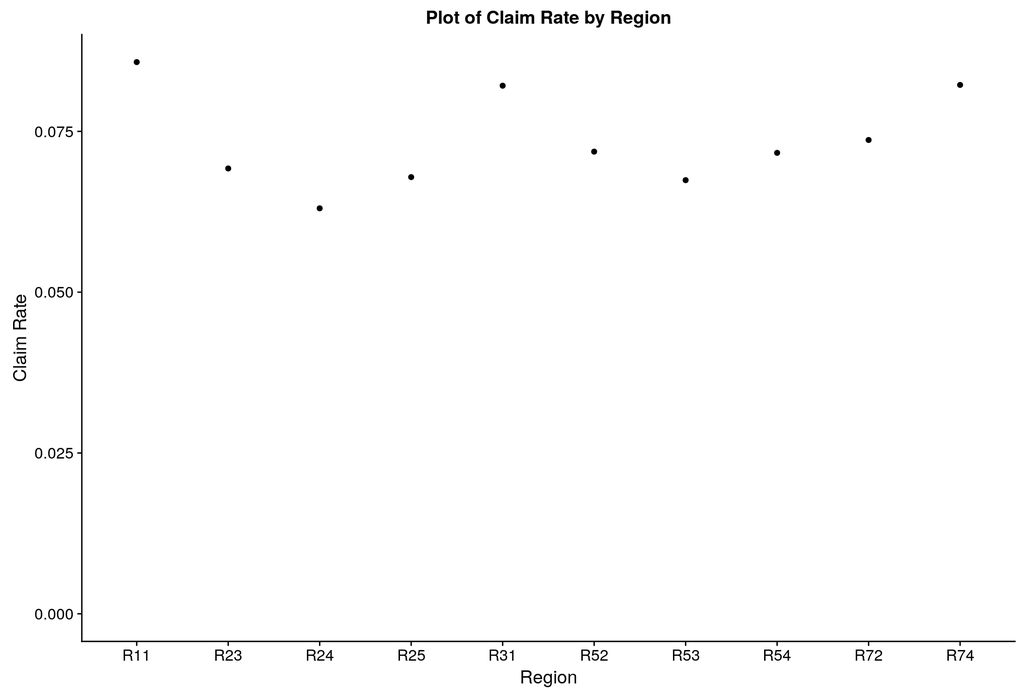

### Claim Rate by Driver Age

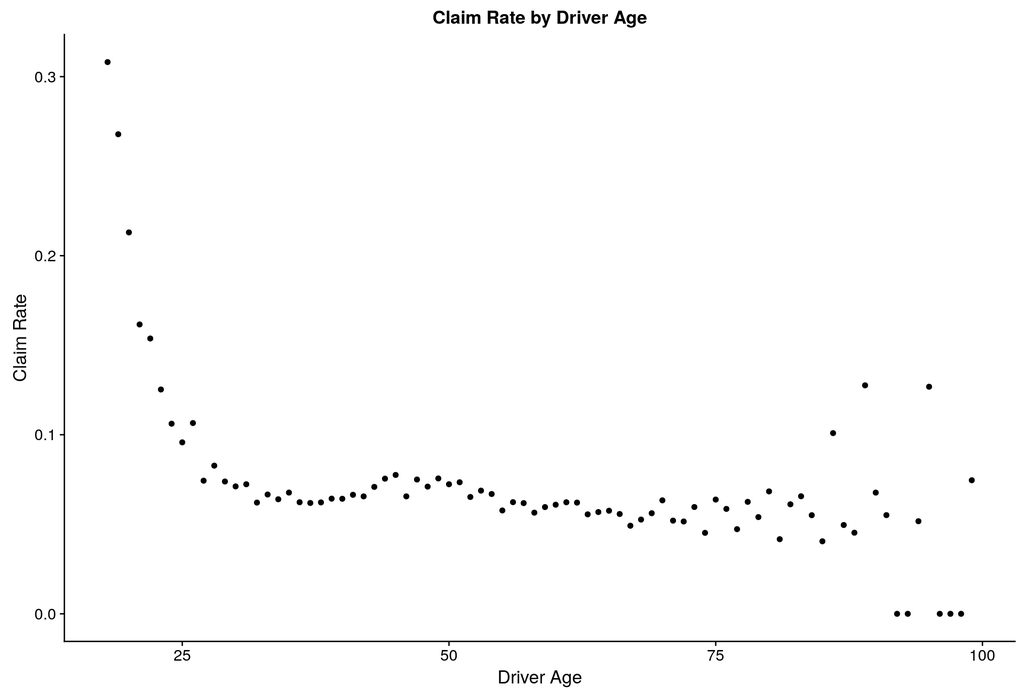

Relationship clearly not linear

Could categorise driver age

Information loss

Use GAM instead

HOWEVER

Simpler to categorise

Will do that here

David Leadbetter

### Categorise Driver Age

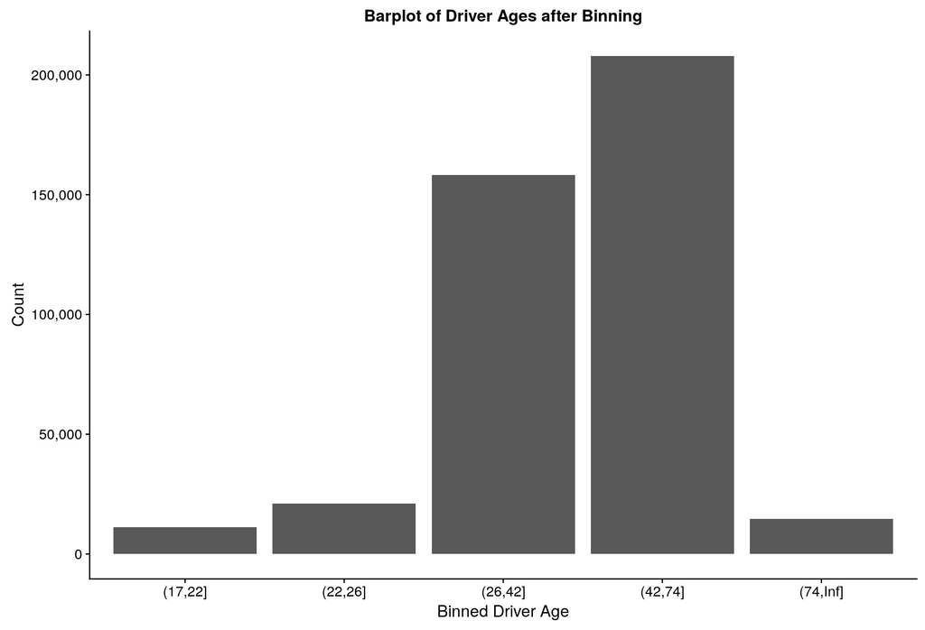

### First Poisson Model

```r
gas_glm <- glm(claim_nb ~ 0 + gas
              ,offset = log(exposure)
              ,data   = policy_tbl
              ,family = poisson)
```

#### Model Diagnostics

| diagnostic | value |
| --- | --- |
| null.deviance | 450746.8 |
| df.null | 413169.0 |
| logLik | -68397.3 |
| AIC | 136798.6 |
| BIC | 136820.4 |
| deviance | 105537.4 |
| df.residual | 413167.0 |

#### Model Coefficients

| term | estimate | std.error | statistic | p.value |
| --- | --- | --- | --- | --- |
| gasDiesel | -2.5946 | 0.0109 | -238.454 | 0 |
| gasRegular | -2.7310 | 0.0114 | -240.193 | 0 |

### Adding Driver Age

```r
expmodel2_glm <- glm(claim_nb ~ gas + cat_driver_age
                    ,offset = log(exposure)
                    ,data   = policy_tbl
                    ,family = poisson)
```

#### Model Diagnostics

| diagnostic | value |
| --- | --- |
| null.deviance | 105612.6 |
| df.null | 413168.0 |
| logLik | -67951.5 |
| AIC | 135915.1 |
| BIC | 135980.7 |
| deviance | 104646.0 |
| df.residual | 413163.0 |

#### Model Coefficients

| term | estimate | std.error | statistic | p.value |
| --- | --- | --- | --- | --- |
| (Intercept) | -2.6369 | 0.0152 | -173.8980 | 0.0000 |
| gasRegular | -0.1488 | 0.0159 | -9.3752 | 0.0000 |
| cat_driver_age(17,22] | 1.0630 | 0.0364 | 29.2362 | 0.0000 |
| cat_driver_age(22,26] | 0.4790 | 0.0342 | 14.0061 | 0.0000 |
| cat_driver_age(42,74] | -0.0172 | 0.0175 | -0.9831 | 0.3255 |
| cat_driver_age(74,Inf] | -0.0913 | 0.0419 | -2.1785 | 0.0294 |

Still just exploration

Will decide on final model later

# Modelling Claim Size

Claim size always positive

Look at distribution of log of claims

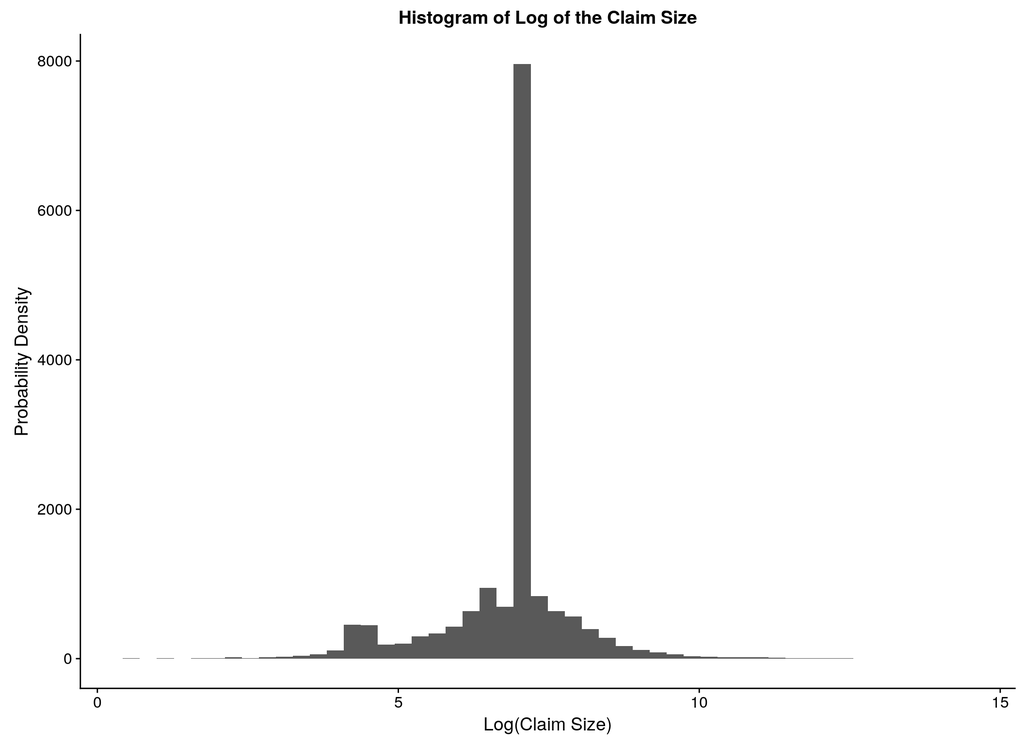

### Linear Model of Log(Claim Size)

```r
expclaim_lm <- lm(log(claim_amount) ~ gas + power + car_age
                 ,data = claimreg_tbl)
```

#### Model Diagnostics

| diagnostic | value |
| --- | --- |
| r.squared | 0.00 |
| adj.r.squared | 0.00 |
| sigma | 1.11 |
| statistic | 2.14 |
| p.value | 0.01 |
| df | 14.00 |
| logLik | -24710.14 |
| AIC | 49450.28 |
| BIC | 49565.66 |
| deviance | 20089.10 |
| df.residual | 16167.00 |

#### Model Coefficients

| term | estimate | std.error | statistic | p.value |
| --- | --- | --- | --- | --- |
| (Intercept) | 6.8698 | 0.0295 | 233.1750 | 0.0000 |
| gasRegular | -0.0114 | 0.0189 | -0.6047 | 0.5454 |
| powere | -0.0138 | 0.0309 | -0.4450 | 0.6563 |
| powerf | 0.0050 | 0.0303 | 0.1641 | 0.8697 |
| powerg | 0.0154 | 0.0300 | 0.5116 | 0.6089 |
| powerh | 0.0455 | 0.0429 | 1.0612 | 0.2886 |
| poweri | 0.0630 | 0.0474 | 1.3278 | 0.1842 |
| powerj | 0.0862 | 0.0480 | 1.7972 | 0.0723 |
| powerk | -0.0079 | 0.0618 | -0.1280 | 0.8982 |
| powerl | 0.0608 | 0.0910 | 0.6676 | 0.5044 |
| powerm | 0.0819 | 0.1299 | 0.6301 | 0.5286 |
| powern | -0.2728 | 0.1507 | -1.8099 | 0.0703 |
| powero | -0.2106 | 0.1535 | -1.3714 | 0.1703 |
| car_age | -0.0061 | 0.0017 | -3.6367 | 0.0003 |

Multiple-$R^2$ of 0.0017???

What does that even look like?

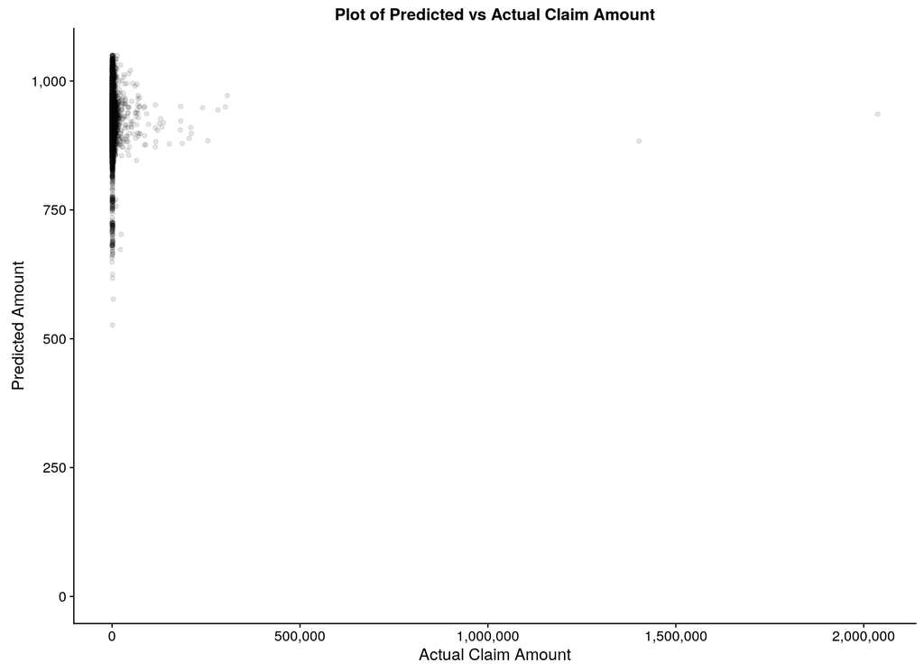

### Linear Model of Attritional Log(Claim Size)

```r
claimreg_tbl <- claimreg_tbl %>% filter(claim_amount < 25000)

expclaim2_lm <- lm(log(claim_amount) ~ gas + power + car_age
                  ,data = claimreg_tbl)
```

#### Model Diagnostics

| diagnostic | value |
| --- | --- |
| r.squared | 0.00 |
| adj.r.squared | 0.00 |
| sigma | 1.06 |
| statistic | 2.29 |
| p.value | 0.01 |
| df | 14.00 |
| logLik | -23714.96 |
| AIC | 47459.92 |
| BIC | 47575.18 |
| deviance | 18007.30 |
| df.residual | 16054.00 |

#### Model Coefficients

| term | estimate | std.error | statistic | p.value |
| --- | --- | --- | --- | --- |
| (Intercept) | 6.8495 | 0.0281 | 243.8822 | 0.0000 |
| gasRegular | -0.0189 | 0.0180 | -1.0492 | 0.2941 |
| powere | -0.0144 | 0.0295 | -0.4883 | 0.6254 |
| powerf | -0.0119 | 0.0289 | -0.4101 | 0.6818 |
| powerg | 0.0028 | 0.0286 | 0.0983 | 0.9217 |
| powerh | 0.0454 | 0.0409 | 1.1110 | 0.2666 |
| poweri | 0.0506 | 0.0452 | 1.1176 | 0.2638 |
| powerj | 0.0849 | 0.0457 | 1.8584 | 0.0631 |
| powerk | -0.0185 | 0.0589 | -0.3136 | 0.7538 |
| powerl | 0.0815 | 0.0865 | 0.9417 | 0.3464 |
| powerm | 0.0023 | 0.1250 | 0.0184 | 0.9853 |
| powern | -0.2481 | 0.1432 | -1.7320 | 0.0833 |
| powero | -0.1853 | 0.1459 | -1.2703 | 0.2040 |
| car_age | -0.0059 | 0.0016 | -3.6439 | 0.0003 |

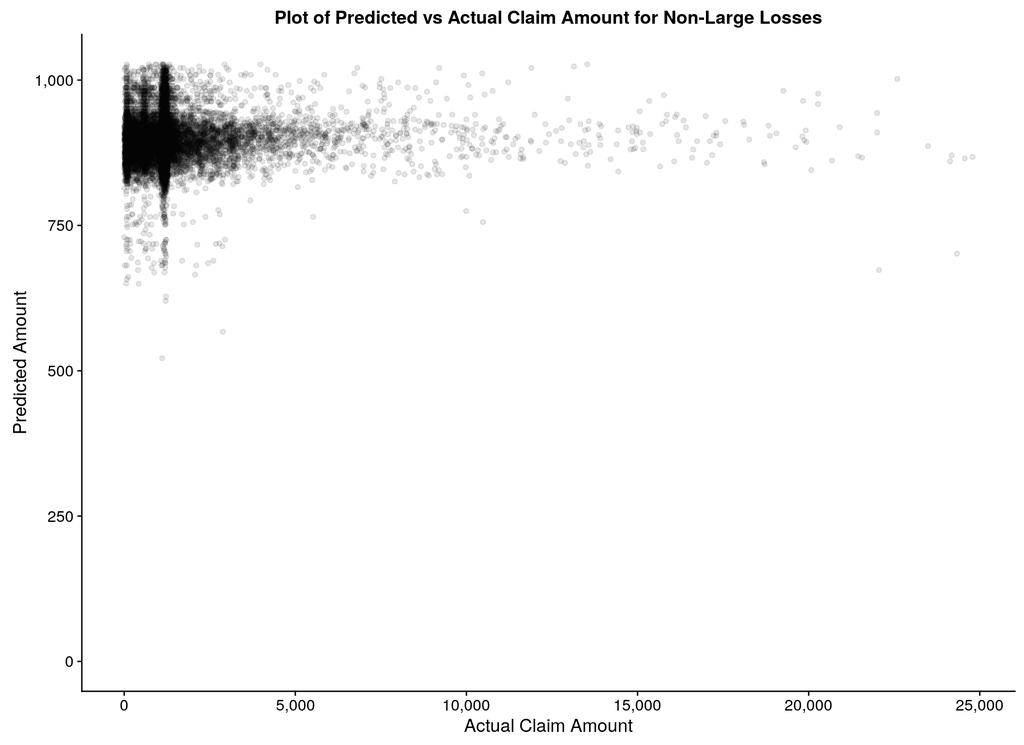

Pretty poor

Fit a Gamma?

### Gamma GLM

```r
claimgamma_glm <- glm(claim_amount ~ gas + power + car_age + cat_driver_age +
                                     cat_driver_age:power
                     ,family = Gamma(link = 'log')
                     ,data   = claimreg_tbl)
```

#### Model Diagnostics

| diagnostic | value |
| --- | --- |
| null.deviance | 14681.1 |
| df.null | 16067.0 |
| logLik | -132367.1 |
| AIC | 264854.3 |
| BIC | 265315.4 |
| deviance | 14470.7 |
| df.residual | 16009.0 |

#### Model Coefficients

| term | estimate | std.error | statistic | p.value |
| --- | --- | --- | --- | --- |
| powere:cat_driver_age(22,26] | -0.0061 | 0.1399 | -0.0436 | 0.9653 |
| car_age | -0.0104 | 0.0019 | -5.4276 | 0.0000 |
| powerh:cat_driver_age(22,26] | -0.0143 | 0.2235 | -0.0640 | 0.9490 |
| cat_driver_age(22,26] | -0.0152 | 0.1068 | -0.1419 | 0.8872 |
| powerk:cat_driver_age(42,74] | 0.0182 | 0.1501 | 0.1213 | 0.9035 |
| powerj:cat_driver_age(74,Inf] | -0.0266 | 0.4029 | -0.0659 | 0.9475 |
| powerl:cat_driver_age(42,74] | -0.0286 | 0.2149 | -0.1329 | 0.8943 |
| gasRegular | -0.0296 | 0.0214 | -1.3817 | 0.1671 |
| powerg:cat_driver_age(42,74] | -0.0381 | 0.0756 | -0.5048 | 0.6137 |
| poweri:cat_driver_age(17,22] | -0.0403 | 0.2266 | -0.1777 | 0.8590 |
| powerk | 0.0420 | 0.1180 | 0.3557 | 0.7221 |
| powerf | 0.0453 | 0.0589 | 0.7693 | 0.4417 |
| powere:cat_driver_age(42,74] | -0.0543 | 0.0775 | -0.7012 | 0.4832 |
| powere | 0.0561 | 0.0613 | 0.9150 | 0.3602 |
| powerj | 0.0561 | 0.0911 | 0.6161 | 0.5378 |
| powerh:cat_driver_age(42,74] | -0.0627 | 0.1053 | -0.5958 | 0.5513 |
| powerk:cat_driver_age(22,26] | -0.0692 | 0.3907 | -0.1771 | 0.8594 |
| powerf:cat_driver_age(42,74] | -0.0700 | 0.0740 | -0.9452 | 0.3446 |
| powerj:cat_driver_age(42,74] | 0.0742 | 0.1165 | 0.6368 | 0.5243 |
| cat_driver_age(42,74] | 0.0749 | 0.0594 | 1.2600 | 0.2077 |

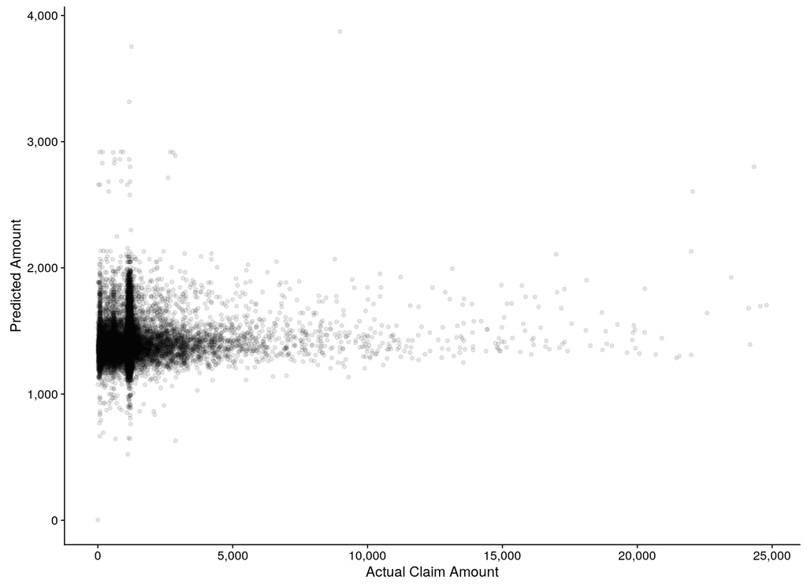

Best to have low expectations

# Model Assessment

# Assessing Frequency Models

Need method of assessment

Deviance, AIC, BIC

Prefer more direct metric

Assess model on predicted counts of claims

Calculate claim rate

Simulate claim counts

Observed vs distribution of expected

# Simulation of Claim Counts

Split train / validation set

Distribution of claim counts for validation

Compare to observed counts

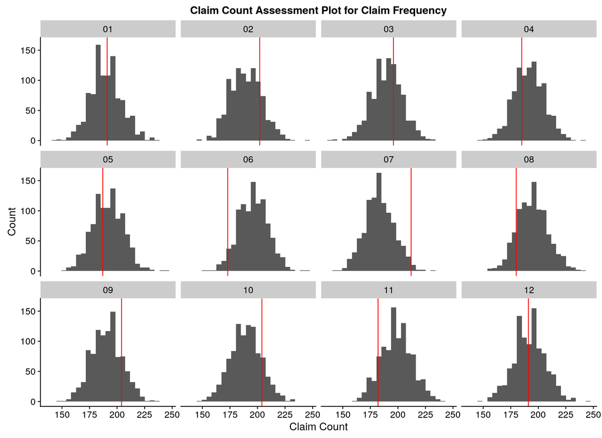

Nice for small fold-count

Distribution of cumulative probabilities

Can extend to full price assessment

# Simulation of Claim Size

Lack of predictive power in claim severity

Still want to capture uncertainty

GLM estimates mean of Gamma

$$X \sim \Gamma(\alpha, \beta)$$

Want uncertainty $\implies$ simulate from Gamma distribution

Need $(\mu, \text{dispersion}) \to (\alpha, \beta)$

$$\begin{eqnarray*}
\alpha &=& \frac{1}{\text{dispersion}} \\
\beta &=& \frac{\alpha}{\mu}
\end{eqnarray*}$$

# Assessment Approach

Train / validation split

Fit model on each split

Use uncertainty at multiple levels

### Simple Frequency/Severity

Per policy claim frequency / severity

Distribution of predicted vs observed

Not much capture of uncertainty

### Simulate Claim Counts

Simulate claim counts from claim rate

Average claim size

Multiply to calculate simulated loss cost

Claim size very noisy

Likely to underestimate variance

### Simulate Claim Count and Size

Simulate claim counts from claim rate

Simulate claim size from prediction

Multiply through for loss calculation

More involved computation

Reasonable estimate of uncertainty / variance

# Building a Premium Quoter

# Data Preparation

Remove drivers older than 75 years

Remove cars older than 20 years

Total size of dataset after filters: 395,068

| policy_id | claim_nb | exposure | power | car_age | driver_age | brand | gas | region | density | cat_driver_age |
| --- | --- | --- | --- | --- | --- | --- | --- | --- | --- | --- |
| 1 | 0 | 0.09 | g | 0 | 46 | Japanese (except Nissan) or Korean | Diesel | R72 | 76 | (42,74] |
| 2 | 0 | 0.84 | g | 0 | 46 | Japanese (except Nissan) or Korean | Diesel | R72 | 76 | (42,74] |
| 3 | 0 | 0.52 | f | 2 | 38 | Japanese (except Nissan) or Korean | Regular | R31 | 3003 | (26,42] |
| 4 | 0 | 0.45 | f | 2 | 38 | Japanese (except Nissan) or Korean | Regular | R31 | 3003 | (26,42] |
| 5 | 0 | 0.15 | g | 0 | 41 | Japanese (except Nissan) or Korean | Diesel | R52 | 60 | (26,42] |
| 6 | 0 | 0.75 | g | 0 | 41 | Japanese (except Nissan) or Korean | Diesel | R52 | 60 | (26,42] |

### Split Data

Standard Train/Test split

Take 100,000 policies for test

| Dataset | Size |
| --- | --- |
| Train | 295,068 |
| Test | 100,000 |

# Model Claim Rate

```r
model_01_glm <- glm(claim_nb ~ cat_driver_age
                   ,offset = log(exposure)
                   ,family = poisson
                   ,data   = trainpolicies_tbl)
```

### Model Diagnostics

| diagnostic | value |
| --- | --- |
| null.deviance | 75606.1 |
| df.null | 295067.0 |
| logLik | -48652.3 |
| AIC | 97314.5 |
| BIC | 97367.5 |
| deviance | 74938.8 |
| df.residual | 295063.0 |

### Model Coefficients

| term | estimate | std.error | statistic | p.value |
| --- | --- | --- | --- | --- |
| (Intercept) | -2.6951 | 0.0157 | -171.4347 | 0.0000 |
| cat_driver_age(17,22] | 1.0513 | 0.0415 | 25.3185 | 0.0000 |
| cat_driver_age(22,26] | 0.4739 | 0.0396 | 11.9533 | 0.0000 |
| cat_driver_age(42,74] | -0.0282 | 0.0203 | -1.3901 | 0.1645 |
| cat_driver_age(74,Inf] | -0.0988 | 0.1214 | -0.8139 | 0.4157 |

# Final Claim Rate Model

```r
model_02_glm <- glm(claim_nb ~ gas + cat_driver_age + car_age + density +
                               cat_driver_age:gas
                   ,offset = log(exposure)
                   ,family = poisson
                   ,data   = trainpolicies_tbl)
```

### Model Diagnostics

| diagnostic | value |
| --- | --- |
| null.deviance | 75606.1 |
| df.null | 295067.0 |
| logLik | -48536.7 |
| AIC | 97097.4 |
| BIC | 97224.5 |
| deviance | 74707.6 |
| df.residual | 295056.0 |

### Model Coefficients

| term | estimate | std.error | statistic | p.value |
| --- | --- | --- | --- | --- |
| (Intercept) | -2.6086 | 0.0250 | -104.2036 | 0.0000 |
| gasRegular | -0.1433 | 0.0320 | -4.4760 | 0.0000 |
| cat_driver_age(17,22] | 1.0211 | 0.0652 | 15.6502 | 0.0000 |
| cat_driver_age(22,26] | 0.5102 | 0.0542 | 9.4185 | 0.0000 |
| cat_driver_age(42,74] | -0.0115 | 0.0274 | -0.4187 | 0.6754 |
| cat_driver_age(74,Inf] | 0.0865 | 0.1972 | 0.4384 | 0.6611 |
| car_age | -0.0086 | 0.0019 | -4.5290 | 0.0000 |
| density | 0.0000 | 0.0000 | 12.3865 | 0.0000 |
| gasRegular:cat_driver_age(17,22] | 0.1467 | 0.0851 | 1.7239 | 0.0847 |
| gasRegular:cat_driver_age(22,26] | -0.0567 | 0.0795 | -0.7126 | 0.4761 |
| gasRegular:cat_driver_age(42,74] | -0.0208 | 0.0409 | -0.5089 | 0.6108 |
| gasRegular:cat_driver_age(74,Inf] | -0.2271 | 0.2505 | -0.9069 | 0.3645 |

# Assess Claim Rate Model

Use predictive checks as before

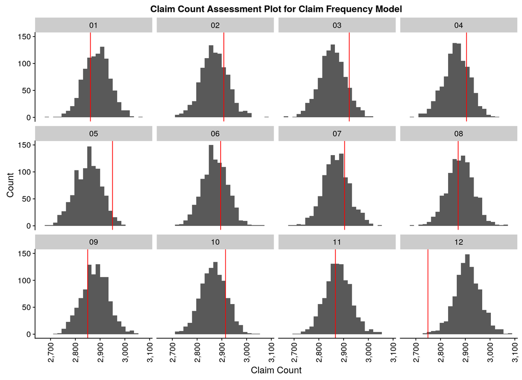

What about claim size?

Models little use

Assume average claim size

```r
claim_tbl %>%
    filter(claim_amount <= 25000) %>%
    summarise(mean_amount = mean(claim_amount))
```

```
## # A tibble: 1 x 1
##   mean_amount
##         <dbl>
## 1     1414.96
```

Use this for claim prediction

# Calculate Large Loss Charge

Estimate large-loss rate

Large losses per unit exposure

Power-law scaling factor

$\alpha = 2.726148$

Use to estimate mean of distribution

$\mu = 59,417.9$

| Quantity | Value |
| --- | --- |
| Loss Expectation | 59,417.9 |
| Large Claim Proportion | 0.000487 |
| Large-loss Charge | 28.96 |

# Create Premium Quoter Function

| policy_id | expect_price | largeloss_charge | risk_premium | quote_price |
| --- | --- | --- | --- | --- |
| 2 | 86.15 | 28.96 | 115.11 | 155.41 |
| 3 | 47.78 | 28.96 | 76.74 | 103.60 |
| 5 | 15.17 | 28.96 | 44.13 | 59.58 |
| 7 | 71.35 | 28.96 | 100.32 | 135.43 |
| 12 | 76.48 | 28.96 | 105.44 | 142.34 |
| 21 | 76.09 | 28.96 | 105.05 | 141.82 |
| 22 | 4.70 | 28.96 | 33.66 | 45.44 |
| 26 | 9.10 | 28.96 | 38.07 | 51.39 |
| 34 | 70.46 | 28.96 | 99.42 | 134.22 |
| 35 | 4.35 | 28.96 | 33.31 | 44.97 |
| 36 | 159.00 | 28.96 | 187.96 | 253.75 |
| 44 | 16.16 | 28.96 | 45.12 | 60.92 |
| 50 | 79.35 | 28.96 | 108.32 | 146.23 |
| 51 | 7.00 | 28.96 | 35.97 | 48.56 |
| 54 | 73.67 | 28.96 | 102.63 | 138.56 |
| 82 | 66.61 | 28.96 | 95.57 | 129.02 |
| 87 | 9.94 | 28.96 | 38.90 | 52.52 |
| 88 | 122.67 | 28.96 | 151.63 | 204.70 |
| 89 | 9.44 | 28.96 | 38.40 | 51.84 |
| 90 | 113.07 | 28.96 | 142.03 | 191.74 |

# Pricing Assessment

# Test-Run Assessment Method

Simulate claims using poisson model

For each claim, simulate claim size

Assign loss-cost to each claim

Compare paid out losses to collected premia

### Assess Training Data

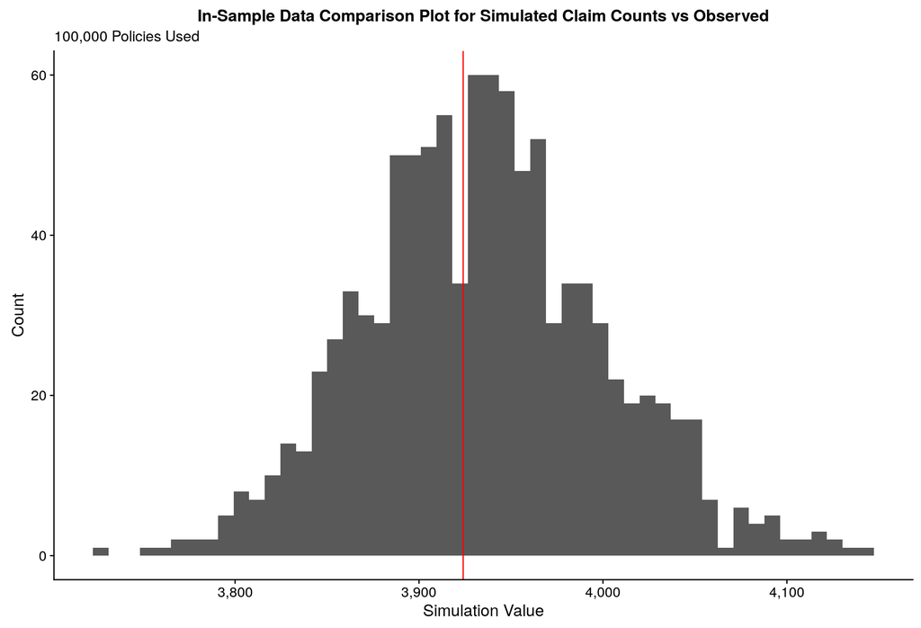

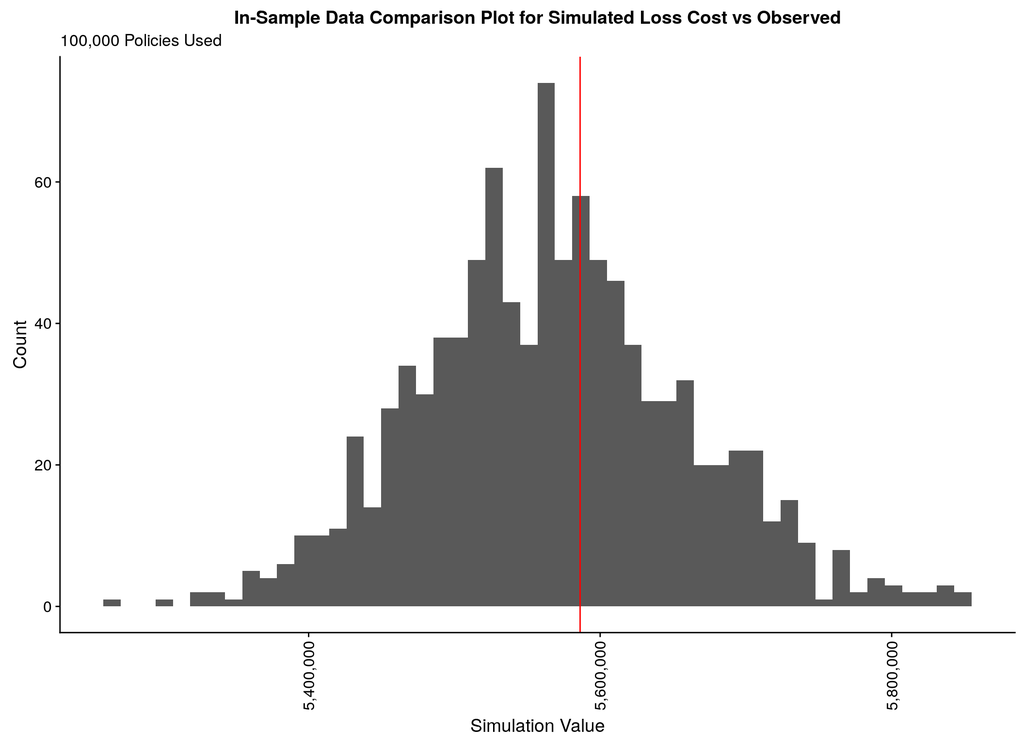

### Assess Out-of-Sample Data

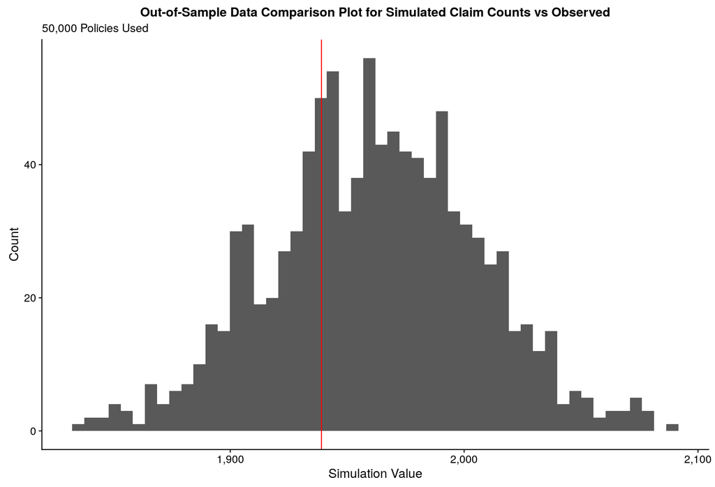

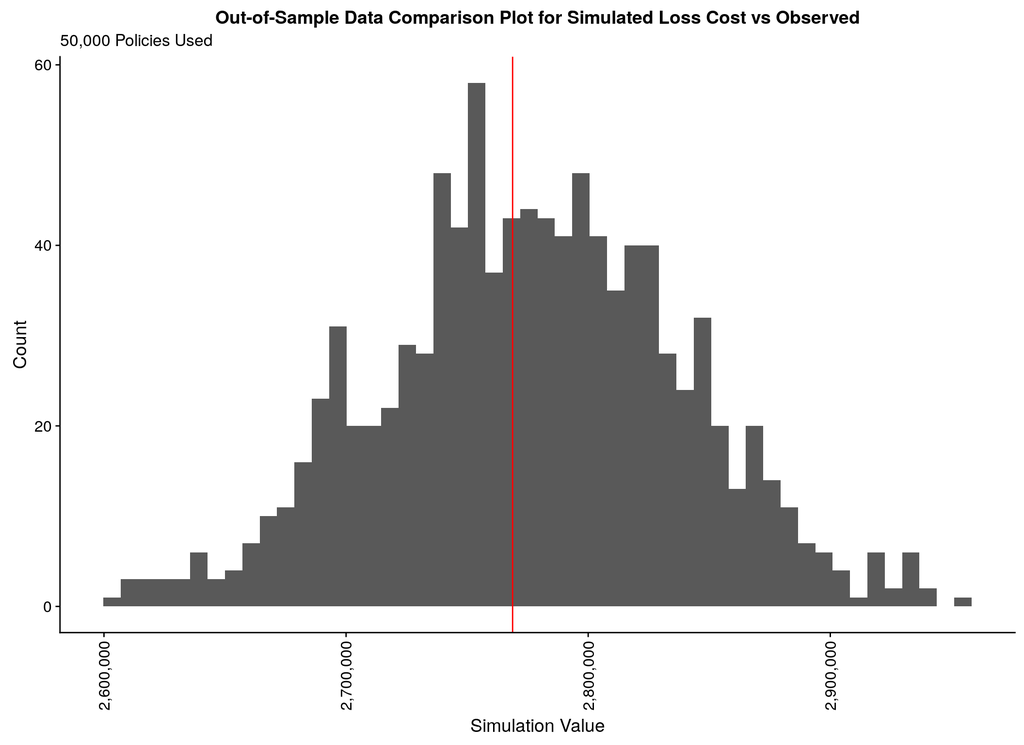

# Adding Claim Size Variation

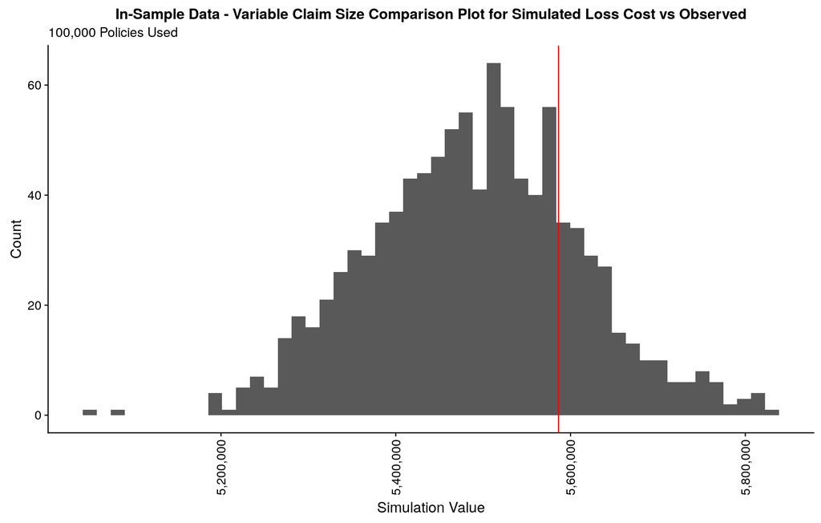

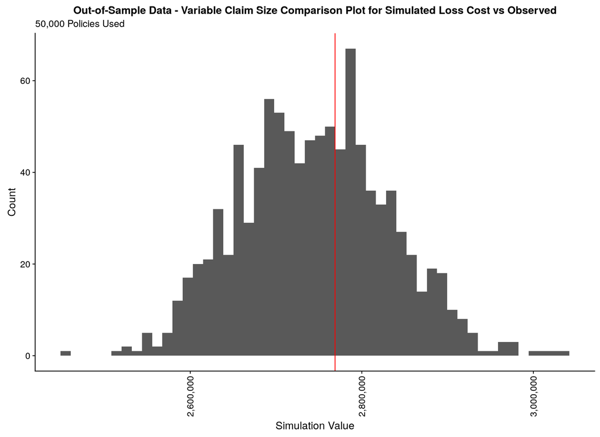

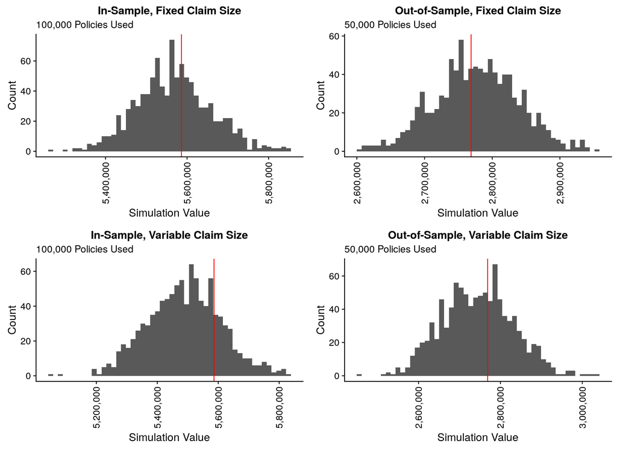